# Linear regression

### Exercise 2: Perform simple linear regression analysis

Using glyhb as Y, waisthipRatio as X

```r
modelResult <- lm(glyhb ~ waisthipRatio, data = diabetes)
```

### Exercise 3: Model interpretation

1. Is waisthipRatio significantly associated with glyhb? What is the coefficient of waisthipRatio? What does it mean?
2. Use a scatter plot to show the waisthipRatio in X axis, and glyhb in Y axis. Add the fitted regression line.
3. Make residual plot to assess the Homoscedasticity assumption.

```r
summary(modelResult)
```

```
##
## Call:
## lm(formula = glyhb ~ waisthipRatio, data = diabetes)
##
## Residuals:
## Glycosolated Hemoglobin
##     Min      1Q  Median      3Q     Max
## -2.9484 -1.2234 -0.6287  0.1206 10.4126
##
## Coefficients:
##               Estimate Std. Error t value Pr(>|t|)
## (Intercept)     0.4189     1.3517   0.310  0.75682
## waisthipRatio   5.8818     1.5291   3.847  0.00014 ***
## ---
## Signif. codes:  0 '***' 0.001 '**' 0.01 '*' 0.05 '.' 0.1 ' ' 1
##
## Residual standard error: 2.204 on 386 degrees of freedom
##   (15 observations deleted due to missingness)
## Multiple R-squared:  0.03692,    Adjusted R-squared:  0.03442
## F-statistic:  14.8 on 1 and 386 DF,  p-value: 0.0001401
```

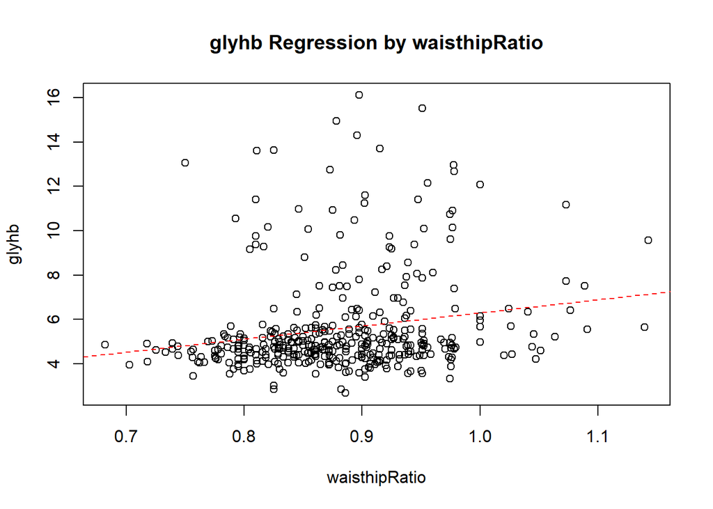

```r
plot(glyhb ~waisthipRatio, data =diabetes,main = "glyhb Regression by waisthipRatio")
abline(modelResult,lty=2,col="red")
```

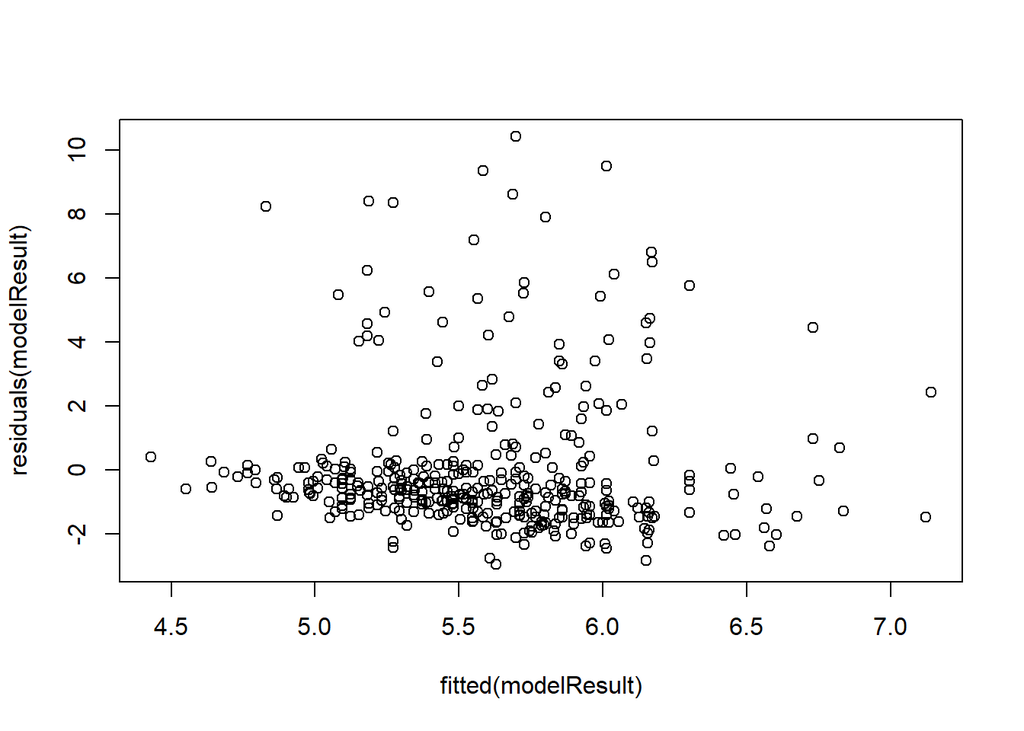

```r
plot(fitted(modelResult),residuals(modelResult))
```

### Exercise 4: Perform multiple linear regression analysis

Using glyhb as Y; waisthipRatio, age, and gender as X

```r
modelResult <- lm(glyhb ~ waisthipRatio+age+gender, data = diabetes)
summary(modelResult)
```

```
##
## Call:
## lm(formula = glyhb ~ waisthipRatio + age + gender, data = diabetes)
##
## Residuals:
## Glycosolated Hemoglobin
##     Min      1Q  Median      3Q     Max
## -3.1019 -1.1576 -0.4675  0.2645 10.2310
##
## Coefficients:
##               Estimate Std. Error t value Pr(>|t|)
## (Intercept)   0.603727   1.430956   0.422    0.673
## waisthipRatio 3.404063   1.617620   2.104    0.036 *
## age           0.041893   0.006779   6.180 1.64e-09 ***
## genderfemale  0.063131   0.231454   0.273    0.785
## ---
## Signif. codes:  0 '***' 0.001 '**' 0.01 '*' 0.05 '.' 0.1 ' ' 1
##
## Residual standard error: 2.107 on 384 degrees of freedom
##   (15 observations deleted due to missingness)
## Multiple R-squared:  0.1243, Adjusted R-squared:  0.1175
## F-statistic: 18.17 on 3 and 384 DF,  p-value: 4.779e-11
```

### Exercise 5: Use the model to predict the glyhb value for a new subject.

```r
newData <- data.frame(age = c(Subject1=3,Subject2=4),waisthipRatio=c(0.7,1.1),gender=c("male","female"))
predict(modelResult,newdata = newData)
```

```
## Subject1 Subject2
## 3.112249 4.578899
```